# Espectadores y futura participación en protestas. El rol de la identidad, la legitimidad y percepción de la violencia

Defensa para optar al título profesional de Socióloga

Moira Martínez Sembler

Facultad de Ciencias Sociales. Universidad de Chile.

Profesora guía: Karina Navarro

14 de enero de 2025

## **Introducción**

### ¿Qué pasa con el que no participa?

- Las protestas se encuentran frescas en la memoria del país, y se han posicionado dentro de las principales discusiones en el espacio público.
  - Estallido social de octubre de 2019, polarización del debate público, resurgimiento de ideas contrarias a la movilización…
- Dentro de este contexto, las personas que no participan de las movilizaciones han sido poco estudiadas, en comparación con las personas que sí participan de este tipo de acción colectiva. Estos son los espectadores.

## **Introducción**

### Contexto de movilizaciones

- Dentro de los predictores importantes de la participación en protestas destaca la identificación con los manifestantes y la legitimidad de la protesta.
- El panorama de las movilizaciones ha estado marcado por el uso de la violencia por parte de los manifestantes y las fuerzas policiales.

**Entonces…**

Interesa abordar estos elementos considerando el particular momento vivido en el país. Por un lado, para **ahondar en la investigación de movimientos sociales y protestas en Chile.** Por otro lado, para **someter a discusión el rol de los espectadores** en la reproducción de los movimientos sociales.

## **Pregunta de investigación**

*¿Cómo influyen la identificación con los manifestantes, la legitimidad de las protestas y la percepción de los entes causantes de la violencia intergrupal en la disposición a participar en protestas futuras de los espectadores de éstas?*

## **Hipótesis**

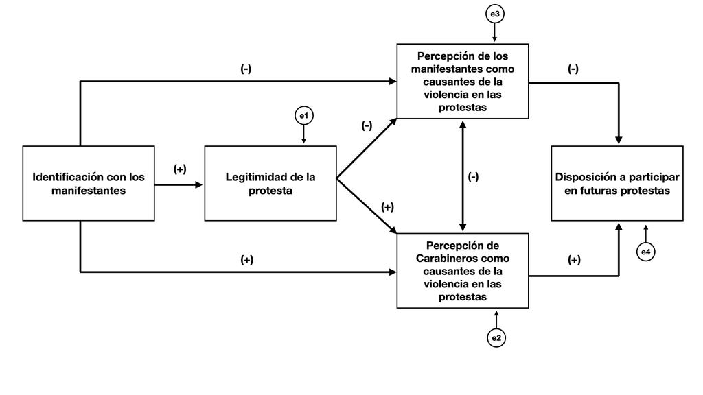

Figura 1. Modelo hipotetizado

## **Método**

- Enfoque **cuantitativo**, encuesta mixta (online y presencial).
- La población objetivo del estudio corresponde a los **espectadores de la protesta en Chile**. La muestra se encontró constituida por espectadores mayores de 18 años en Chile que no participaron en actividades relacionadas con las protestas en los últimos 5 años, exceptuando el Estallido Social.
- Muestreo por cuotas representativas según nivel socioeconómico y género. Representación de Santiago y Concepción. La muestra total alcanzó las **935 personas**.
- El foco del análisis se encontró en la utilización de modelos de *ecuaciones estructurales*.

## **Resultados**

### *Modelo teórico*

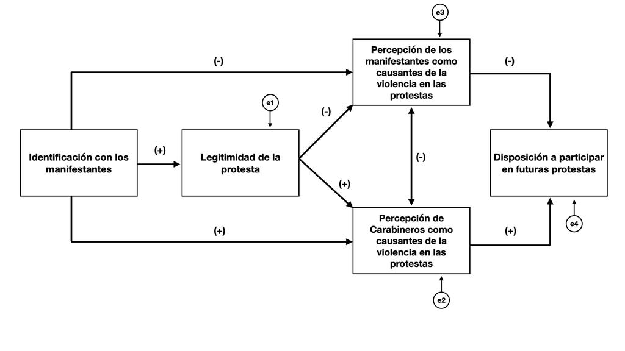

Figura 1. Modelo hipotetizado

## **Resultados**

### *Modelo final*

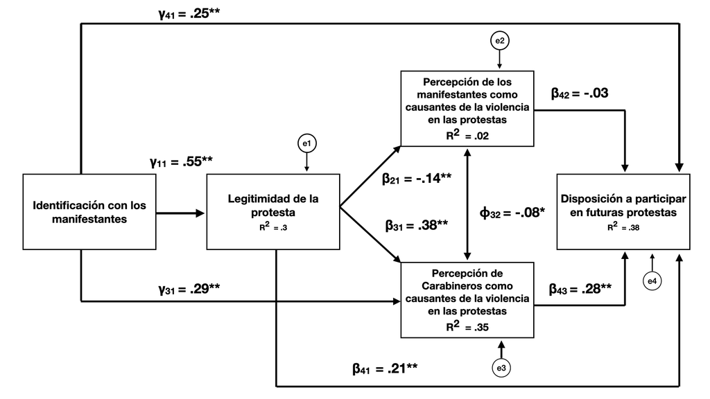

Figura 2. Modelo final

## **Resultados**

### *Identificación con los manifestantes*

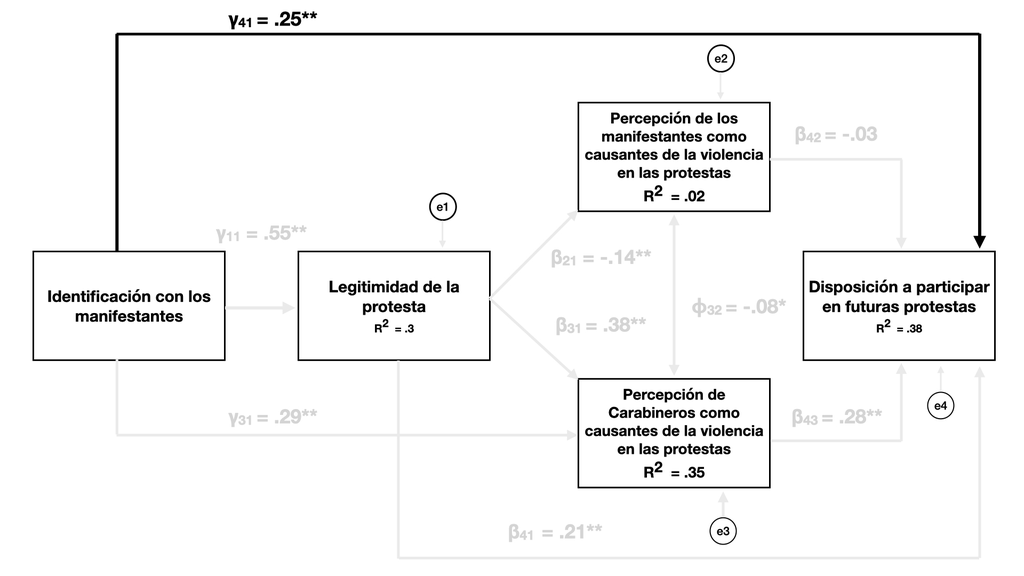

## **Resultados**

### *Identificación con los manifestantes*

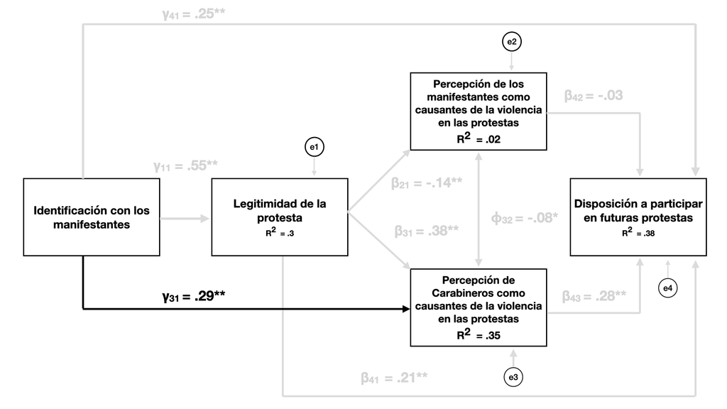

## **Resultados**

### *Identificación con los manifestantes*

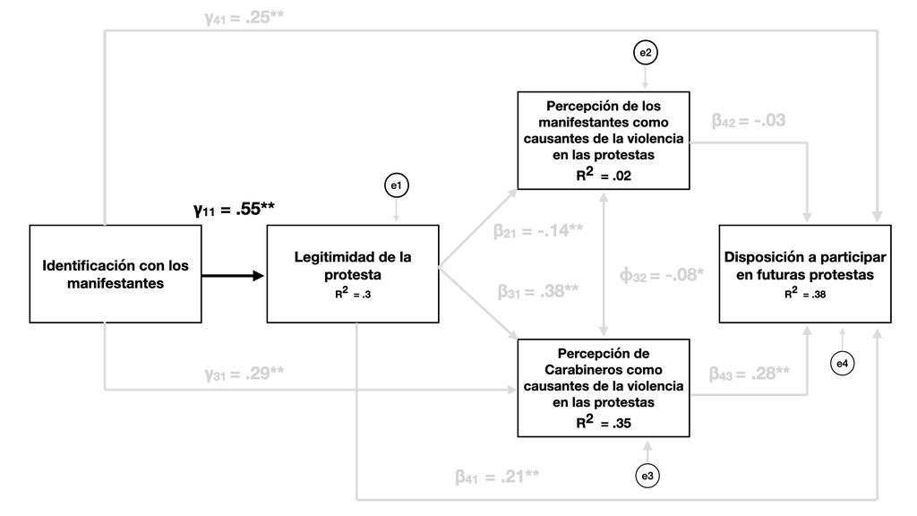

## **Resultados**

### *Legitimidad de la protesta*

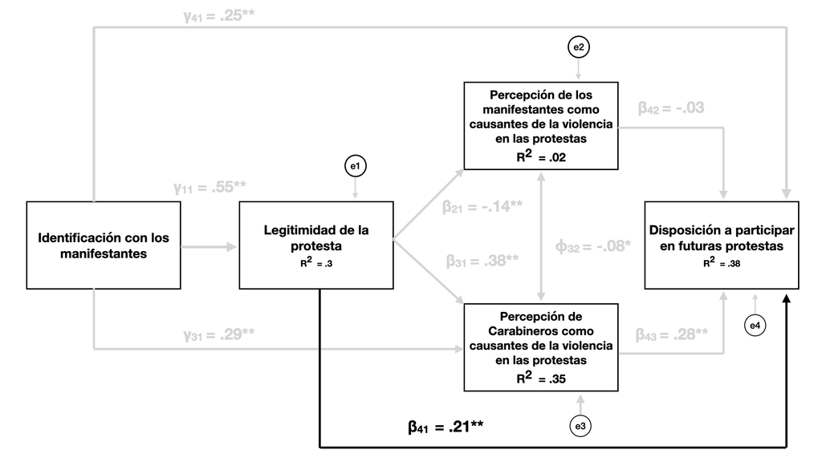

## **Resultados**

### *Legitimidad de la protesta*

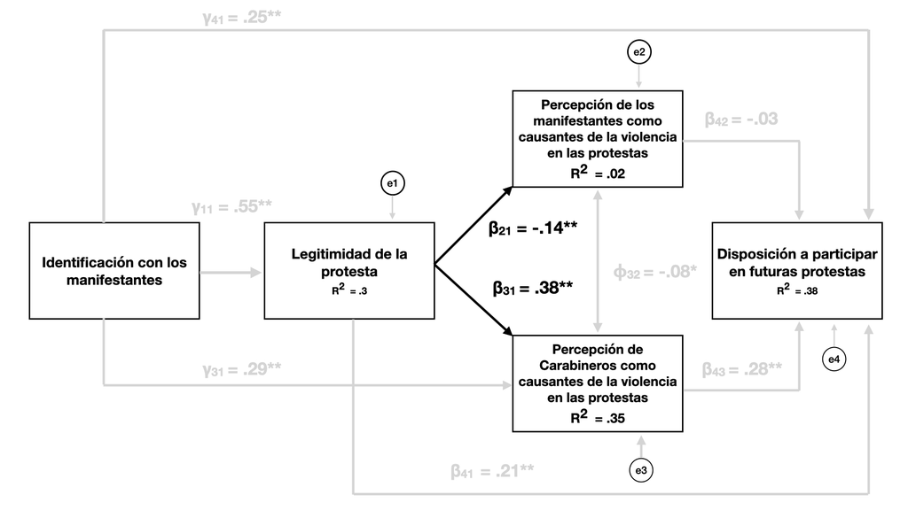

## **Resultados**

### *Percepción de violencia*

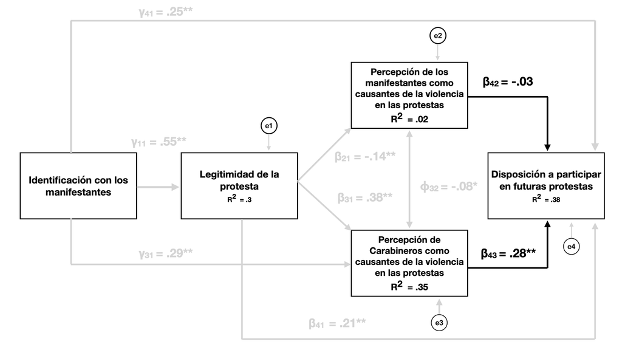

## **Conclusiones**

- **El espectador**, un actor novedoso, activo lector de las manifestaciones.
- Los espectadores que se identifican más con los manifestantes y ven las protestas como legítimas son más propensos a participar en futuros actos de protesta. Evaluaciones contextuales pueden moldear su disposición hacia la protesta.
- La percepción de los Carabineros como causantes de la violencia en las protestas también tiene un efecto positivo en la disposición a participar. Al percibir el actuar de Carabineros como injusto, los espectadores son capaces de posicionarse.
- Ausencia de relación entre culpar a los manifestantes de la violencia en las protestas y la futura participación de los espectadores en estas. Percepción de la violencia en las protestas por parte de los espectadores no es polarizada, sino más bien contextual.

## **Limitaciones y estudios futuros**

- Operacionalización de variables. Considerar variables latentes.
- Uso de variables de contexto como género, nivel educacional, ideología política, uso de medios de comunicación.
- Medición a largo tiempo. observar las diferencias entre los espectadores que efectivamente asistieron a una protesta y quienes no asistieron a una protesta.
- **Explorar a los espectadores en un escenario cada vez más incierto**. Trabajar en conceptualizar a este grupo.